# Lista de Exercícios 2 - ADAR/UFSM

Rodrigo da Silva Pereira

2022-01-10

1. Crie um vetor com os valores de $e^{x}cos{x}$ para os valores de $x = (3, 3.1, 3.2, ..., 6$).

```r
x <- c(seq(from = 3, to = 6, by = 0.1))
(y <- exp(x) * cos(x))
 [1] -19.884531 -22.178753 -24.490697 -26.773182 -28.969238 -31.011186
 [7] -32.819775 -34.303360 -35.357194 -35.862834 -35.687732 -34.685042
[13] -32.693695 -29.538816 -25.032529 -18.975233 -11.157417  -1.362099
[19]  10.632038  25.046705  42.099201  61.996630  84.929067 111.061586
[25] 140.525075 173.405776 209.733494 249.468441 292.486707 338.564378
[31] 387.360340
```

2. Crie os seguintes vetores.
   1. $(0.1^{3}\times0.2^{1}, 0.1^{6}\times0.2^{4}, ..., 0.1^{36}\times0.2^{34})$
   2. $(2, \frac{2^{2}}{2}, \frac{2^{3}}{3}, ..., \frac{2^{25}}{25})$

```r
aa <- seq(3, by = 3, length.out = 12)
ab <- seq(1, by = 3,length.out = 12)

ac <- 1:25

#Resposta 2a
(a <- c(rep((0.1^aa * 0.2^ab), length.out = 12)))
 [1] 2.000000e-04 1.600000e-09 1.280000e-14 1.024000e-19 8.192000e-25
 [6] 6.553600e-30 5.242880e-35 4.194304e-40 3.355443e-45 2.684355e-50
[11] 2.147484e-55 1.717987e-60

#Resposta 2b
(b <- rep((2^ac / ac), length.out = 25))
 [1] 2.000000e+00 2.000000e+00 2.666667e+00 4.000000e+00 6.400000e+00
 [6] 1.066667e+01 1.828571e+01 3.200000e+01 5.688889e+01 1.024000e+02
[11] 1.861818e+02 3.413333e+02 6.301538e+02 1.170286e+03 2.184533e+03
[16] 4.096000e+03 7.710118e+03 1.456356e+04 2.759411e+04 5.242880e+04
[21] 9.986438e+04 1.906502e+05 3.647221e+05 6.990507e+05 1.342177e+06
```

3. Reproduza a criação do vetor dias da semana (`dds`) mostrado abaixo.

```
domingo segunda   terca  quarta  quinta   sexta   sabado
      1       2       3       4       5       6        7
```

```r
(dds <- c(domingo = 1, segunda = 2, terca = 3, quarta = 4, quinta = 5,
          sexta = 6, sabado = 7))
domingo segunda   terca  quarta  quinta   sexta  sabado
      1       2       3       4       5       6       7
```

4. Interprete o resultado da seguinte operação:

```r
dds_nums <- c(
  5L, 2L, 5L, 2L, 7L, 7L, 2L,
  6L, 6L, 3L, 7L, 1L, 2L, 2L,
  5L, 7L, 3L, 2L, 6L, 4L, 1L
)
names(dds)[dds_nums]
```

Resposta 4: Ao usarmos o sufixo “L” após um dado numérico, definimos que este dado é do tipo inteiro. A linha de comando “names(dds)[dds_nums]” mostra os nomes das variáveis em que estão no vetor “dds_nums”. - - -

5. Para um ano ser bissexto, ele deve ser:
- divísivel por 4 (a divisão é exata com resto igual a zero)
- não pode ser divisível por 100 (a divisão não é exata, ou seja, o resto é diferente de zero)
- pode ser que seja divisível por 400: caso seja divisível por 400, a divisão deve ser exata, deixando o resto igual a zero.

  Com os critérios definidos acima, construa o código para:
  1. Verificar se os anos 1894, 1947, 1901, 1992, 1925, 2014, 1993, 1996, 1984, 1897, 2100, 2300 são bissextos.
  2. Mostre quais anos são bissextos.
  3. Usando o código para verificar se o ano é bissexto, gere um vetor nomeado `ndias` com o número de dias do ano para os anos do item (a).
  4. Programe como obter o total de anos com 366 dias?

```r
set.seed(3)
(anos <- c(sample(1890:2015, 10), 2100, 2300))
 [1] 1894 1947 1901 1992 1925 2014 1993 1996 1984 1897 2100 2300
(condicao_1 <- c(anos %% 4))
 [1] 2 3 1 0 1 2 1 0 0 1 0 0
(condicao_2 <- anos %% 100)
 [1] 94 47  1 92 25 14 93 96 84 97  0  0
(condicao_3 <- anos %% 400)
 [1] 294 347 301 392 325  14 393 396 384 297 100 300
```

```r
anos_bissextos <- ifelse(  test = (condicao_1 == 0)
& (condicao_2 != 0) | (condicao_3 == 0),
  yes = "sim",  no = "não")
anos_bissextos
 [1] "não" "não" "não" "sim" "não" "não" "não" "sim" "sim" "não" "não" "não"
```

```r
(local_bissextos <- which(anos_bissextos == "sim"))
[1] 4 8 9
anos[local_bissextos]
[1] 1992 1996 1984
```

```r
ndias <- ifelse(
  test = (condicao_1 == 0) & (condicao_2 != 0) | (condicao_3 == 0),  yes = 366,
  no = 365)
names(ndias) <- anos
ndias
1894 1947 1901 1992 1925 2014 1993 1996 1984 1897 2100 2300
 365  365  365  366  365  365  365  366  366  365  365  365
```

```r
total_anos_bissextos <- ifelse(
  test = ndias == 366,
  yes = 1,
  no = 0
)
sum(total_anos_bissextos)
[1] 3
```

6. Quais códigos para gerar os seguintes dados:

```
[1] -30   0   5  10  15  20  30
```

```r
Vetor_s <- c(-30, seq(0, 20, by = 5), 30)
Vetor_s
[1] -30   0   5  10  15  20  30
```

```
[1] 1.0 0.8 0.6 0.4 0.2 0.0
```

```r
vetor_t <- seq(from = 1.0, to = 0.0, by = -0.2)
vetor_t
[1] 1.0 0.8 0.6 0.4 0.2 0.0
```

```
[1] -3.1415927 -2.4434610 -1.7453293 -1.0471976 -0.3490659  0.3490659
[7]  1.0471976  1.7453293  2.4434610  3.1415927
```

```r
vetor_k  <- seq(-pi, pi, length.out  = 10)
vetor_k
 [1] -3.1415927 -2.4434610 -1.7453293 -1.0471976 -0.3490659  0.3490659
 [7]  1.0471976  1.7453293  2.4434610  3.1415927
```

```
[1] -1 -1  0  0  0  1  1  1  1  2  2  2  2  2  3  3  3  3  3  3  4  4  4
[24]  4  4  4  4  5  5  5  5  5  5  5  5
```

```r
vetor_d <- rep(x = -1:5, times = 2:8)
vetor_d
 [1] -1 -1  0  0  0  1  1  1  1  2  2  2  2  2  3  3  3  3  3  3  4  4  4  4  4
[26]  4  4  5  5  5  5  5  5  5  5
```

```
[1] 5 5 5 5 5 4 4 4 4 3 3 3 2 2 1 2 2 3 3 3 4 4 4 4 5 5 5 5 5
```

```r
vetor_a <- rep(x = 5:1, times = 5:1)

vetor_b <- rep(x = 2:5, times = 2:5)

(vetor_e <- c(vetor_a, vetor_b))
 [1] 5 5 5 5 5 4 4 4 4 3 3 3 2 2 1 2 2 3 3 3 4 4 4 4 5 5 5 5 5
```

7. Usando o mesmo código para solução em todos os itens abaixo, obtenha as seguintes sequências usando os vetores fornecidos.
1. v3 = (11, 0.25, 7, 2)

```
[1] 1 2 3 4
```

```r
v3 <- c(11, 0.25, 7, 2)
seq(along = v3)
[1] 1 2 3 4
```

2. v2 = (11, 0.25)

```
[1] 1 2
```

```r
v2 <- v3[1:2]
seq(along = v2)
[1] 1 2
```

3. v1 = (11)

```
[1] 1
```

```r
v1 <- v3[1]
seq(along = v1)
[1] 1
```

4. v0 = ()

```
integer(0)
```

```r
v0 <- c()
seq_along(v0)
integer(0)
```

8. Considere os seguintes dados horários de temperatura do ar ($T_{ar}$) registrados em duas estações meteorológicas, entre as 0 e 23 horas de um dado dia.

```r
tar_est1 <- c(
  14.92, 14.61, 14.32, 14.07, 13.84, 13.65, 13.56, 13.97, 15.08,
  16.5, 17.88, 19.08, 20.02, 20.66, 21.01, 21.05, 20.76, 20.05,
  18.77, 17.51, 16.67, 16.11, 15.66, 15.27
)
tar_est2 <- c(
  13.13, 13.01, 12.93, 12.87, 12.82, 12.81, 13.2, 14.22, 15.77,
  17.49, 19.2, 20.57, 21.49, 22.01, 22.03, 21.71, 20.84, 18.77,
  16.54, 15.13, 14.34, 13.81, 13.49, 13.28
)
```

> Dica: Faça um gráfico para visualizar as temperaturas das duas estações. Isso facilitará a solução.

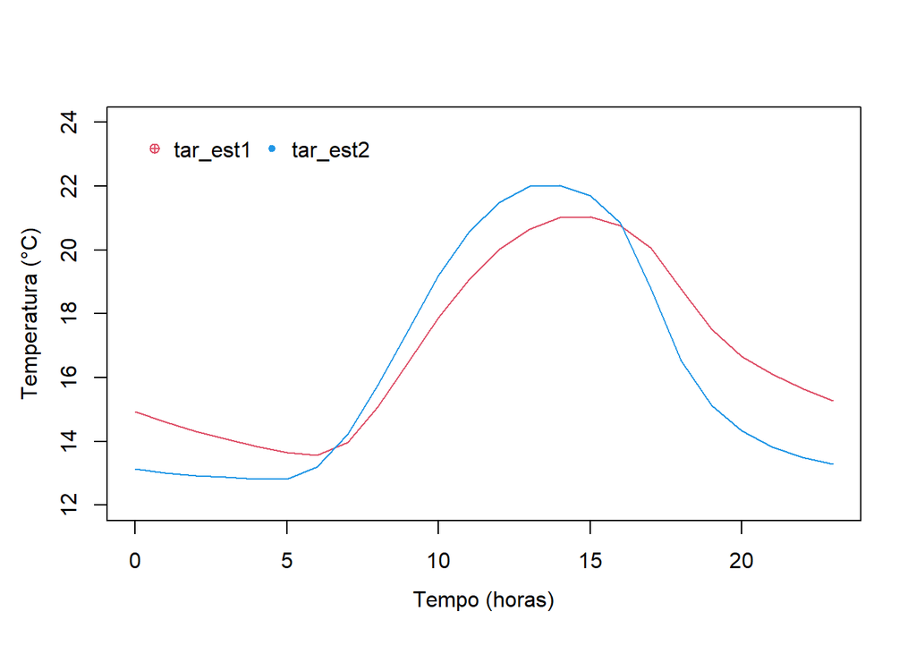

```r
temp <- seq(from = 0, to = 23, by = 1)
plot(temp, tar_est1, type = "l", pch = 10, col = 2, xlab = "", ylab = "", ylim = c(12,24))
lines(temp, tar_est2,type = "l", col = 4, pch = 20)
mtext(side = 1, "Tempo (horas)", line = 2.5, cex = 1)
mtext(side = 2, "Temperatura (°C)", line = 2.5, cex = 1)
legenda <- c("tar_est1","tar_est2")
legend(0, 24, legenda, col = c(2,4), pch = c(10,20), bty = "n", cex = 1, ncol = 2)
```

**a.** Determine a média diária da $T_{ar}$ das duas estações arrendondando para uma casa decimal. Salve a média de cada estação nas variáveis `tmed_est1` e `tmed_est2`.

```r
tmed_est1 <- mean(tar_est1)
(tmed_est1 <- round(tmed_est1, 1))
[1] 16.9
tmed_est2 <- mean(tar_est2)
(tmed_est2 <- round(tmed_est2, 1))
[1] 16.3
```

**b**. Utilizando as variáveis do item anterior, verifique usando comparação lógica, em qual estação o ambiente é mais quente?

```r
if (tmed_est1 - tmed_est2 == 0)
{print("tmed_est1 = tmed_est2")}
if(tmed_est1 - tmed_est2 > 0)
{print("tmed_est1")} else {print("tmed_est2")}
[1] "tmed_est1"
```

**c**. Obtenha a 3ª maior temperatura do dia em cada estação.

```r
tar_est1[order(tar_est1, decreasing = TRUE)][3]
[1] 20.76

tar_est2[order(tar_est2, decreasing = TRUE)][3]
[1] 21.71
```

**d**. Calcule a amplitude térmica diária ($ATD = T_{max}-T_{min}$, onde $T_{max}$: temperatura máxima dária e $T_{min}$: temperatura mínima dária) das estações 1 e 2, arrendondando para uma casa decimal. Salve os resultados nas variaveis `atd_est1` e `atd_est2`.

```r
max1 <- which.max(tar_est1)
min1 <- which.min(tar_est1)
(atd_est1 <- round(tar_est1[max1] - tar_est1[min1], 1))
[1] 7.5

max2 <- which.max(tar_est2)
min2 <- which.min(tar_est2)
(atd_est2 <- round(tar_est2[max2] - tar_est2[min2], 1))
[1] 9.2
```

**e**. Qual o horário de ocorrência das temperaturas máximas e mínimas em cada estação? Salve os resultados nas variáveis `hmax_est{i}` e `hmin_est{i}`, com $i = 1, 2$.

```r
(hmax_est1 <- max1)
[1] 16
(hmin_est1 <- min1)
[1] 7

(hmax_est2 <- max2)
[1] 15
(hmin_est2 <- min2)
[1] 6
```

**f**. Quando `tar_est2` é maior que `tar_est1` qual a maior diferença absoluta de temperatura entre as duas estações?

```r
(dif_tar_ests  <- which(tar_est2 > tar_est1))
 [1]  8  9 10 11 12 13 14 15 16 17
max(tar_est2 - tar_est1)
[1] 1.49
```

**g**. Qual a hora correspondende a ocorrência daquela maior diferença absoluta de temperatura obtida no item anterior?

```r
(hora <- which.max(tar_est2 - tar_est1))
[1] 12
```

**h**. O horário do pôr do sol pode ser estimado a partir da $T_{ar}$. Para o período após o horário de ocorrência da $T_{max}$ determina-se em qual hora ocorre a maior queda de $T_{ar}$ em relação a hora anterior. Estime o horário do pôr do sol para as duas estações (`hps_est{i}`).

```r
#Horário estimado do pôr do sol para a estação 1
(dif_est1 <- diff(tar_est1[hmax_est1:23]))
[1] -0.29 -0.71 -1.28 -1.26 -0.84 -0.56 -0.45
(h_dif_max <- which.max(abs(dif_est1)))
[1] 3
(hps_est1 <- hmax_est1 + h_dif_max)
[1] 19

#Horário estimado do pôr do sol para a estação 2
(dif_est2 <- diff(tar_est2[hmax_est2:23]))
[1] -0.32 -0.87 -2.07 -2.23 -1.41 -0.79 -0.53 -0.32
(h_dif_max <- which.max(abs(dif_est2)))
[1] 4

(hps_est2 <- hmax_est2 + h_dif_max)
[1] 19
```

**i**. Em quais horas as temperaturas das duas estações estão mais próximas uma da outra, ou seja com menos de 0,5°C de diferença ?

```r
(dif_tar_ests <- abs(tar_est1 - tar_est2))
 [1] 1.79 1.60 1.39 1.20 1.02 0.84 0.36 0.25 0.69 0.99 1.32 1.49 1.47 1.35 1.02
[16] 0.66 0.08 1.28 2.23 2.38 2.33 2.30 2.17 1.99
(menor_dif <- which(dif_tar_ests < 0.5))
[1]  7  8 17
```

**j**. Calcule a temperatura média diária usando os seguintes métodos para estação 2.

$T_{med_{1}} = (T_{max} + T_{min})/2$, salvando em uma variável `tar_met1`.

```r
Tmax2 <- tar_est2[which.max(tar_est2)]
Tmin2 <- tar_est2[which.min(tar_est2)]

(tar_met1 <- (Tmax2 + Tmin2)/2)
[1] 17.42
```

$T_{med_{2}} = (T_{max} + T_{min} + T_{9} + 2T_{21})/5$, salvando em uma variável `tar_met2`.

```r
Tmax2 <- tar_est2[which.max(tar_est2)]
Tmin2 <- tar_est2[which.min(tar_est2)]
(tar_met2 <- (Tmax2 + Tmin2 + tar_est2[9] + 2* tar_est2[21])/5)
[1] 15.858
```

$T_{med_{3}} = (T_{7} + T_{14} + 2T_{21})/4$, salvando em uma variável `tar_met3`.

```r
Tmax2 <- tar_est2[which.max(tar_est2)]
Tmin2 <- tar_est2[which.min(tar_est2)]
(tar_met3 <- (tar_est2[7] + tar_est2[14] + 2*tar_est2[21])/4)
[1] 15.9725
```

Compare estes resultados com aqueles obtidos no item **a**. Qual é melhor?

Resposta: Ao comparar o resultado obtido no item **a** (16,3°C), percebesse que o valor encontrado usando o método $T_{med_{3}}$ apresenta um valor mais próximo daquele. O uso do terceiro método é melhor, haja vista que este método descarta os valores extremos de temperatura (mínima e máxima) observados na estação 2.

9. Calcule a temperatura do ar horária usando o **modelo de onda** para representação do ciclo diário da temperatura do ar, descrito pelas seguintes equações:

$$\left\{\begin{matrix}
h_{T_{min}}\leq h < h_{T_{max}}, & T_{calc} = \bar{T} - A \, cos\left ( arg \right )\\
demais\; horas, & T_{calc} = \bar{T} + A \, cos\left ( arg \right )
\end{matrix}\right.$$

onde:

$$\bar{T} = \left ( \frac{T_{max} + T_{min}}{2} \right )$$

e

$$A =\left ( \frac{T_{max}-T_{min}}{2} \right )$$

O argumento do cosseno ($arg$) é definido por:

$$\left\{\begin{matrix}
h < h_{T_{min}}, & arg = \pi \left ( \frac{h+10}{10+h_{Tmin}} \right )\\
h_{T_{min}}\leq h < h_{T_{max}}, & arg = \pi \left ( \frac{h-h_{T_{min}}}{14-h_{T_{min}}} \right )\\
h > h_{T_{max}}, & arg = \pi\left ( \frac{14-h}{10+h_{Tmin}} \right )
\end{matrix}\right.$$

**a**. Aplique o método acima para estação 1 e 2 substituindo os valores de $T_{max}$, $T_{min}$, $h_{T_{max}}$, $h_{T_{max}}$, adequadamente.

```r
h <- seq(from = 0, to = 23, by = 1)

T_med1 <- (tar_est1[max1] + tar_est1[min1])/2
T_med2 <- (tar_est2[max2] + tar_est2[min2])/2

A1 <- (tar_est1[max1] - tar_est1[min1])/2
A2 <- (tar_est2[max2] - tar_est2[min2])/2

## Estação 1

arg11 <- ifelse(h < hmin_est1, pi*((h + 10)/(10 + hmin_est1)), NA )
arg11 <- arg11[!is.na(arg11)]

Tcalc11 <- T_med1 + A1*cos(arg11)

arg12 <- c()
for (h in 0:23) {
    if (hmin_est1 <= h && h < hmax_est1) {
    arg12[h] <- pi*((h - hmin_est1)/(14 - hmin_est1))
  }

}
arg12 <- arg12[!is.na(arg12)]
Tcalc12 <- T_med1 - A1*cos(arg12)

h <- seq(from = 0, to = 23, by = 1)
arg13 <- ifelse(h >= hmax_est1, pi*((14 - h)/(10 + hmin_est1)), NA )
arg13 <- arg13[!is.na(arg13)]
Tcalc13 <- T_med1 + A1*cos(arg13)

(Tcalc1 <- c(Tcalc11, Tcalc12, Tcalc13))
 [1] 16.28013 15.63571 15.04813 14.53741 14.12094 13.81289 13.62377 13.56000
 [9] 13.93087 14.97003 16.47166 18.13834 19.63997 20.67913 21.05000 20.67913
[17] 20.79711 20.48906 20.07259 19.56187 18.97429 18.32987 17.65055 16.95945

## Estação 2

h <- seq(from = 0, to = 23, by = 1)

arg21 <- ifelse(h < hmin_est2, pi*((h + 10)/(10 + hmin_est2)), NA )
(arg21 <- arg21[!is.na(arg21)])
[1] 1.963495 2.159845 2.356194 2.552544 2.748894 2.945243

Tcalc21 <- T_med2 + A2*cos(arg21)

arg22 <- c()
for (h in 0:23) {
    if (hmin_est2 <= h && h < hmax_est2) {
    arg22[h] <- pi*((h - hmin_est2)/(14 - hmin_est2))
  }

}
(arg22 <- arg22[!is.na(arg22)])
[1] 0.0000000 0.3926991 0.7853982 1.1780972 1.5707963 1.9634954 2.3561945
[8] 2.7488936 3.1415927
Tcalc22 <- T_med2 - A2*cos(arg22)

h <- seq(from = 0, to = 23, by = 1)
arg23 <- ifelse(h >= hmax_est2, pi*((14 - h)/(10 + hmin_est2)), NA )
(arg23 <- arg23[!is.na(arg23)])
[1] -0.1963495 -0.3926991 -0.5890486 -0.7853982 -0.9817477 -1.1780972 -1.3744468
[8] -1.5707963 -1.7671459
Tcalc23 <- T_med2 + A2*cos(arg23)

(Tcalc2 <- c(Tcalc21, Tcalc22, Tcalc23))
 [1] 15.65583 14.85882 14.16024 13.58693 13.16092 12.89858 12.81000 13.16092
 [9] 14.16024 15.65583 17.42000 19.18417 20.67976 21.67908 22.03000 21.94142
[17] 21.67908 21.25307 20.67976 19.98118 19.18417 18.31937 17.42000 16.52063
```

**b**. Calcule o RMSE nos dois casos. $RMSE = \sqrt{\frac{1}{n}\sum_{i=1}^{n}\left (T_{calc}-T_{obs} \right )^{2}}$

```r
## RMSE para a estação 1

caso1 <- (Tcalc1 - tar_est1)^2
(n1 <- length(Tcalc1))
[1] 24
(RMSE_1 <- sqrt((1/n1)*sum(caso1)))
[1] 1.188466

## RMSE para a estação 2

caso2 <- (Tcalc2 - tar_est2)^2
(n2 <- length(Tcalc2))
[1] 24
(RMSE_2 <- sqrt((1/n1)*sum(caso2)))
[1] 2.435634
```

**c**. Calcule a correlação ($r$) nos dois casos. A barra representa a média aritmética.

$$r = \frac{\sum_{i=1}^{n} (T_{obs}-\bar{T}_{obs})(T_{calc}-\bar{T}_{calc}))}{\sqrt{\sum_{i = 1}^{n} (T_{obs}-\bar{T}_{obs})^{2}(T_{calc}-\bar{T}_{calc})^{2})}}$$

```r
## Estação 1
caso1_cal1 <- Tcalc1 - mean(Tcalc1)
caso1_ob1 <- tar_est1 - mean(tar_est1)
(n1 <- sum(caso1_ob1*caso1_cal1))
[1] 150.3042

som1 <- sum(caso1_ob1^2)
som2 <- sum(caso1_cal1^2)
som3 <- som1*som2

(r <- n1/sqrt(som3))
[1] 0.9099943

## Estação 2

caso2_cal2 <- Tcalc2 - mean(Tcalc2)
caso2_ob2 <- tar_est2 - mean(tar_est2)
(n2 <- sum(caso2_ob2*caso2_cal2))
[1] 214.7864

som4 <- sum(caso2_ob2^2)
som5 <- sum(caso2_cal2^2)
som6 <- som4*som5

(r <- n2/sqrt(som6))
[1] 0.7933669
```